# HR model building

Mai Nguyen

March 28, 2018

First of all, we import all the necessary packages for this model building

```r
library(readxl)
HR <- read_excel('~/Desktop/MBA study/Courses/Data Analytics Materials/Learning R/HW6.xls')

library(tidyverse)
library(car)
library(MASS)
library(leaps)
```

We turn Engineer variable into indicator variables.

```r
HR <- HR %>% mutate(Engineer_Yes = case_when(Engineer == 'Yes' ~ 1, Engineer == 'No' ~ 0, TRUE ~ NA_real_))
```

Step 1: Run the multiple linear regression with all variables:

```r
fit <- lm( formula = Sales ~ Wonder + SC + Experience + Engineer_Yes, data = HR)
summary(fit)
```

```
##
## Call:
## lm(formula = Sales ~ Wonder + SC + Experience + Engineer_Yes,
##     data = HR)
##
## Residuals:
##     Min      1Q  Median      3Q     Max
## -45.440  -5.633   1.863   6.750  21.187
##
## Coefficients:
##              Estimate Std. Error t value Pr(>|t|)
## (Intercept)  25.76834   13.95370   1.847   0.0722 .
## Wonder       -0.01341    0.40498  -0.033   0.9737
## SC            1.35142    0.19471   6.941 2.27e-08 ***
## Experience    0.16816    0.52871   0.318   0.7521
## Engineer_Yes  7.27471    4.10113   1.774   0.0837 .
## ---
## Signif. codes:  0 '***' 0.001 '**' 0.01 '*' 0.05 '.' 0.1 ' ' 1
##
## Residual standard error: 11.74 on 40 degrees of freedom
## Multiple R-squared:  0.5932, Adjusted R-squared:  0.5526
## F-statistic: 14.58 on 4 and 40 DF,  p-value: 1.979e-07
```

At 10% significance level, we can see that p-values of SC and Engineer_Yes are smaller than 0.1. P-value of the other variables (Wonder and Experience) are quite high.

Next, we check VIF of each variable to see wherther there is multicolinearity problem:

```r
vif(fit)
```

```
##       Wonder           SC   Experience Engineer_Yes
##     1.119579     1.130583     1.030854     1.013864
```

VIF of all variables are small, therefore we infer that there is no multicolinearity problem.

Step 2: We use stepwise regression to get the best model

```r
step <- stepAIC(fit, direction = 'both')
```

```
## Start:  AIC=226.39
## Sales ~ Wonder + SC + Experience + Engineer_Yes
##
##                Df Sum of Sq     RSS    AIC
## - Wonder        1       0.2  5515.2 224.39
## - Experience    1      13.9  5529.0 224.50
## <none>                       5515.0 226.38
## - Engineer_Yes  1     433.8  5948.8 227.79
## - SC            1    6641.9 12156.9 259.95
##
## Step:  AIC=224.39
## Sales ~ SC + Experience + Engineer_Yes
##
##                Df Sum of Sq     RSS    AIC
## - Experience    1      13.8  5529.0 222.50
## <none>                       5515.2 224.39
## - Engineer_Yes  1     436.7  5951.9 225.82
## + Wonder        1       0.2  5515.0 226.38
## - SC            1    7303.8 12818.9 260.34
##
## Step:  AIC=222.5
## Sales ~ SC + Engineer_Yes
##
##                Df Sum of Sq     RSS    AIC
## <none>                       5529.0 222.50
## - Engineer_Yes  1     440.0  5969.0 223.94
## + Experience    1      13.8  5515.2 224.39
## + Wonder        1       0.0  5529.0 224.50
## - SC            1    7370.2 12899.1 258.62
```

The best model includes only SC and Engineer_yes as the independent variables. Run the linear regression again, we have:

```r
Stepwisefit <- lm(formula = Sales ~ SC + Engineer_Yes, data = HR)
summary(Stepwisefit)
```

```
##
## Call:
## lm(formula = Sales ~ SC + Engineer_Yes, data = HR)
##
## Residuals:
##     Min      1Q  Median      3Q     Max
## -44.582  -5.398   1.691   7.100  20.978
##
## Coefficients:
##              Estimate Std. Error t value Pr(>|t|)
## (Intercept)   26.8910     9.7718   2.752  0.00871 **
## SC             1.3408     0.1792   7.482 2.99e-09 ***
## Engineer_Yes   7.2869     3.9857   1.828  0.07462 .
## ---
## Signif. codes:  0 '***' 0.001 '**' 0.01 '*' 0.05 '.' 0.1 ' ' 1
##
## Residual standard error: 11.47 on 42 degrees of freedom
## Multiple R-squared:  0.5922, Adjusted R-squared:  0.5728
## F-statistic:  30.5 on 2 and 42 DF,  p-value: 6.598e-09
```

We have Sales = 26.8910 + 1.3408 * SC + 7.2869 * Engineer_Yes Every point increase in SC test will lead to 1.3408 unit increase in Target value of Sales. Applicants who have Engineer Degree will have higher targeted value of Sales by 7.2869 than applicants who don’t have Enginner Degree.

Step 3: Regression Diagnotics Nomarlity check:

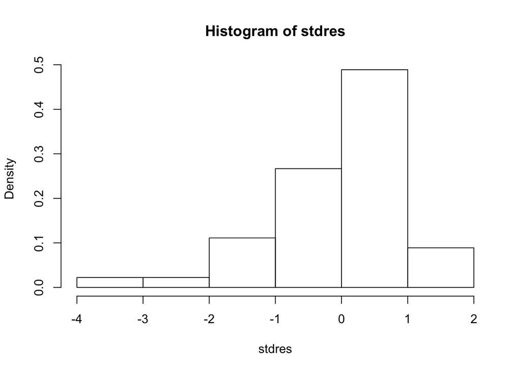

```r
stdres <- rstandard(Stepwisefit)
hist(stdres, freq = FALSE)
```

From the histogram, we see that the residual is approximately normally distributed.

Next, we check the constant variance condition:

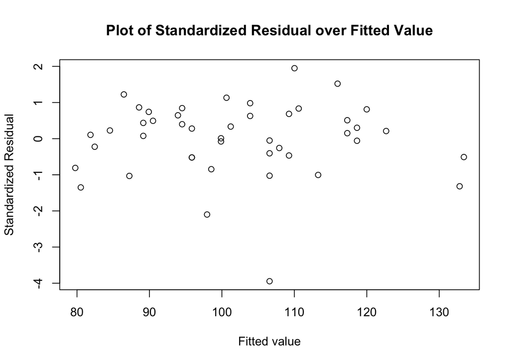

```r
fittedvalue <- fitted(Stepwisefit)
plot(fittedvalue, stdres, main = "Plot of Standardized Residual over Fitted Value", xlab = "Fitted value", ylab = "Standardized Residual")
```

From the graph, it seems that there is no pattern between Residuals and Fitted Values. We conclude that there is no heteroscadacity problem.

Next, we check the autocorrelation condition:

```r
durbinWatsonTest(Stepwisefit)
```

```
##  lag Autocorrelation D-W Statistic p-value
##    1    -0.008344354      2.011072   0.946
##  Alternative hypothesis: rho != 0
```

Result, intepretation and recommendation

1, Best model: Sales = 26.8910 + 1.3408 * SC + 7.2869 * Engineer_Yes

2, Wonderlic test is not significant in determining the sales performance of applicants. The SC test is. Therefore, the company should keep SC test but drop Wonderlic test.

3, The model also indicates that having an engineer background is important in having a good sales performance. Best applicant for sales position will be the one who have engineer background and have achieved high score of SC test.